# Session4

Ottar N. Bjornstad

2023-11-08

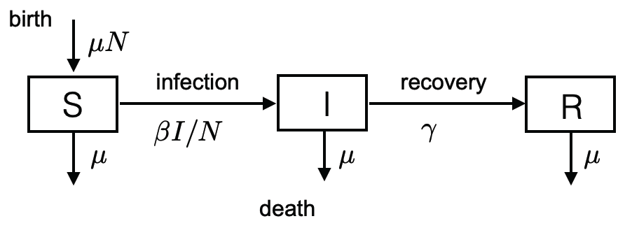

From Session 2-3:

The basic equations for the flow of hosts between **S**usceptible, **I**nfectious and **R**ecovered compartments are:

$\begin{aligned} \frac{dS}{dt} =& \underbrace{\mu N}_{\mbox{birth}} - \underbrace{\beta I \frac{S}{N}}_{\mbox{infection}} - \underbrace{\mu S}_{\mbox{death}} \label{eq:sirs}\\ \frac{dI}{dt} =& \underbrace{\beta I \frac{S}{N}}_{\mbox{infection}} - \underbrace{\gamma I}_{\mbox{recovery}} - \underbrace{\mu I}_{\mbox{death}} \label{eq:siri}\\ \frac{dR}{dt} =& \underbrace{\gamma I}_{\mbox{recovery}} - \underbrace{\mu R}_{\mbox{death}} \label{eq:sirr} \end{aligned}$

```r
require(epimdr2)
require(deSolve)
```

**STEP 1**: Define the function (often called the gradient functions) for the equation systems. The deSolve package requires the function to take the following parameters: time *t* a vector with the values for the state variables (in this case $S$, $I$ and $R$) *y* and parameter values (for $\beta$, $\mu$, $\gamma$, and $N$) *parameters*:

```r
 sirmod=function(t, y, parameters){
   #Pull state variables from y vector
   S=y[1]
   I=y[2]
   R=y[3]
   #Pull parameter values from the input vector
   beta=parameters["beta"]
   mu=parameters["mu"]
   gamma=parameters["gamma"]
   N=parameters["N"]
   #Define equations
   dS = mu * (N  - S)  - beta * S * I / N
   dI = beta * S * I / N - (mu + gamma) * I
   dR = gamma * I - mu * R
   res=c(dS, dI, dR)
   #Return list of gradients
   list(res)
 }
```

```r
times  = seq(0, 0.5, by=1/365)
 paras  = c(mu = 0, N = 1, R0=4, gamma = 365/14)
 paras["beta"]=paras["R0"]*(paras["gamma"]+paras["mu"])
 start = c(S=0.999, I=0.001, R = 0)*paras["N"]
```

```r
out = ode(y = start, times = times, func = sirmod,
     parms = paras)
out=as.data.frame(out)
head(round(out, 3))
```

```
##    time     S     I     R
## 1 0.000 0.999 0.001 0.000
## 2 0.003 0.999 0.001 0.000
## 3 0.005 0.998 0.002 0.000
## 4 0.008 0.998 0.002 0.000
## 5 0.011 0.997 0.002 0.000
## 6 0.014 0.996 0.003 0.001
```

Plot:

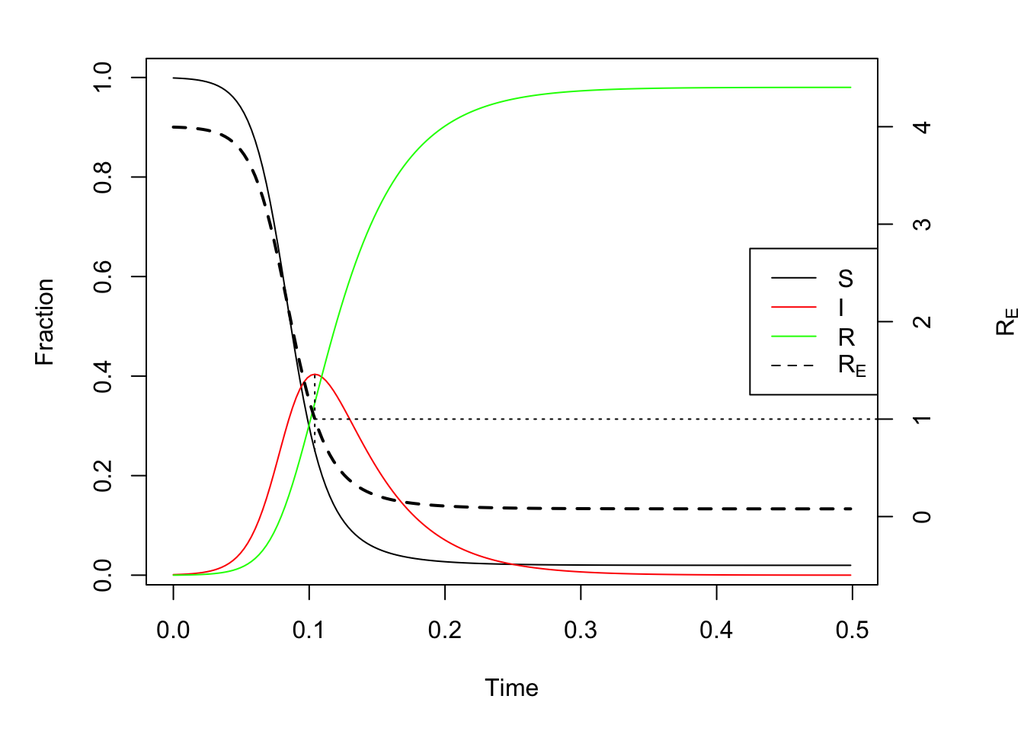

```r
R0 = paras["R0"]
#Adjust margins to accommodate a second right axis
par(mar = c(5, 5, 2, 5))
#Plot state variables
plot(x = out$time, y = out$S, ylab = "Fraction",
     xlab = "Time",  type = "l")
lines(x = out$time, y = out$I, col = "red")
lines(x = out$time, y = out$R, col = "green")

#Add vertical line at turnover point
xx = out$time[which.max(out$I)]
lines(c(xx, xx), c(1/R0, max(out$I)), lty = 3)

#prepare to superimpose 2nd plot
par(new = TRUE)
#plot effective reproduction number (w/o axes)
plot(x = out$time, y = R0*out$S, type = "l", lty = 2,
     lwd = 2, col = "black", axes = FALSE, xlab = NA,
     ylab = NA, ylim = c(-.5, 4.5))
lines(c(xx, 26), c(1, 1), lty = 3)
#Add right-hand axis for RE
axis(side = 4)
mtext(side = 4, line = 4, expression(R[E]))
#Add legend
legend("right", legend = c("S", "I", "R",
     expression(R[E])), lty = c(1, 1, 1, 2),
     col = c("black", "red", "green", "black"))
```

*Reproduction numbers and control*

The *basic reproction number* $R_0$ is the expected number of secondary cases from an index case in a completely susceptible population. The *effective* reproduction number ($R_E$) is the expected number of new cases per infected individuals in a **not** completely susceptible population. The plot confirms that the turnover of the epidemic happens exactly when $R_E = R_0 s =1$, where $s$ is the fraction of remaining susceptibles. The threshold $R_0 s = 1 \Rightarrow s = 1/R_0$ results in the powerful rule of thumb for  
vaccine induced elimination and **herd immunity**: If, through vaccination, the susceptible population is kept below a critical fraction, $p_c = 1-1/R_0$, then pathogen spread will dissipate and the pathogen will not be able to reinvade the host population. This rule of thumb appeared to work well for smallpox, the only vaccine-eradicated human disease; Its $R_0$ was commonly around 5, and most countries saw elimination once vaccine cover exceeded 80%.

We can explore $p_c$ as a function of $R_0$:

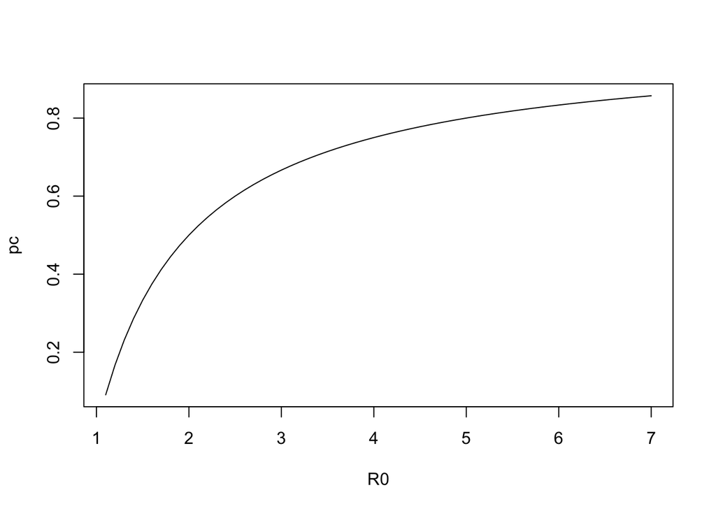

```r
R0=seq(from=1.1, to=7, by=0.1)
pc=1-1/R0
plot(x=R0, y=pc, type="l")
```

In a closed epidemic the *peak prevalence* is $1-(1+\log R_0)/R_0$ and the early doubling time is $\log(2) V / \log R_0$, where $V$ is the serial interval (the average infection-to-onwards-transmission time). We can consider the peak prevalence which is important for flattening the curve and doubling time. For Covid V was 5ish days:

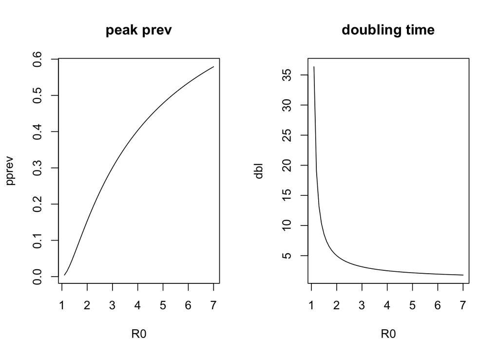

```r
R0=seq(from=1.1, to=7, by=0.1)
pprev=1-(1+log(R0))/R0
V=5
dbl=log(2) * V /log(R0)
par(mfrow=c(1,2)) #side by side plots
plot(x=R0, y=pprev, type="l")
title("peak prev")
plot(x=R0, y=dbl, type="l")
title("doubling time")
```